# cFIT Tutorial

6 July 2021

# 1 Introduction

cFIT (common Factor Space Integration & Transfer) is a tool for data integration and transfer for scRNAseq data. It is applied to data from multiple labs and experimental conditions, technologies and even species.

Our proposed method models the shared information between various data sets by a common factor space, while allowing for unique distortions and shift per batch. The model parameters are learned under and iterative non-negative matrix factorization (NMF) framework and then used for synchronized intefration from across-domain assays. In addtion, the model enables transferring via low-rank matrix from more informative data to allow for precise identification of data of lower quality.

# 2 Getting started

First load the package

```r
library(cFIT)
options(warn = -1)
```

We illustrate the standard workflow of data integration as well as data transfer, using well analyzed pancreas islet cells dara sets, retrieved from `SeuratData` package (Stuart et al. (2019)).

```r
library(SeuratData)
# InstallData("panc8") # if not installed, require memory of 118MB
data("panc8")
```

## 2.1 Data integration

cFIT integration is composed of the following procedure:

- Gene selection. Select highly variable genes that are shared among data sources. Here we adopt the proposed procedure from [Seurat V3](https://satijalab.org/seurat/).
- Data preprocessing. Library size normalization and log transformation
- Model parameter estimation. The model parameters are estimated throught iterative NMF
- Post processing, evaluation, and downstream analysis.

The `panc8` is saved as Seurat object, we extract the raw expression and cell metadata.

```r
# extract the raw counts and metadata for data sets from 5 technologies
data.list = split_dataset_by_batch(X=t(as.matrix(panc8@assays$RNA@counts)),
                                   batch = panc8@meta.data$tech,
                                   labels = panc8@meta.data$celltype,
                                   metadata = panc8@meta.data,
                                   dataset.name = 'panc:')
```

Select 2000 highly variable genes

```r
# select highly variable genes
genes = select_genes(data.list$X.list, ngenes=2000, verbose=F)
```

Preprocess to normalize by library size and log transform

```r
# data preprocessing
exprs.list = preprocess_for_integration(data.list$X.list, genes, scale.factor=10^4, scale=T, center=F)
```

We first integrate data sets from four technologies (inDrop, celseq, celseq2, SmartSeq2), and then transfer the learned factor matrix to the smallest dataset–fluidigmc1.

Perform data integration with `CFITIntegrate`. The only parameter to adjust is `r`, which is the number of factors of the common factor matrix (shared across datasets). The algorithm is relatively robust to `r` as long as r approximate the number of underlying distinct cell types across all data sets. Other minor parameters that can be adjusted is `max.niter` (100 by default), `tol` tolerance used in stopping criteria (1e-5 by default), `gamma` tunning of the penalty term (1e6 by default), `nrep` number of repeats of the run (1 by default, require much longer if increased), `init` parameter initialization (NULL). The parallel is control by `future` R package, by default `sequential` plan is used. To enable parallel computation, set `future.plan='multicore` and set the `workers` as the number of cores to use. Note that Rstudio does not support ‘multicore.’

```r
# integrate four largest datasets, takes roughly 20 minutes to run
ref.data = c(1,2,3,5)
int.out = CFITIntegrate(X.list=exprs.list[ref.data], r=15, max.niter=100, future.plan='sequential', seed=0, verbose=F)
```

```
#> INFO [2021-07-06 03:58:03] Converge at iter 85, obj delta = 8.11451195061401e-06
```

```r
# For large datasets we recommende using the sketched version for fast convergence.
# int.out = CFITIntegrate_sketched(X.list=exprs.list[ref.data], r=15, subsample.prop = 0.1,
#                                  max.niter=100, early.stopping=10, tol=1e-8,
#                                  future.plan='sequential', seed=42, verbose=F)
```

The output is a list containing

- estimated model parameters, common factor matrix `W`, factor loading matrices (per datasets) `H.list`, dataset specific scaling `lambda.list` and shift `b.list`
- convergence status `convergence`, number of iterations `niter`, and final objective function value `obj`, final objective delta `delta`
- parameters used for the function call, including `gamma`, `max.iter`, `tol`, `rep`

We obtain the integrated data via

```r
# ncell-by-ngene expression matrix
exprs.int = do.call(rbind, int.out$H.list) %*% t(int.out$W)

# ncell-by-r low dimensiional representation
Hnorm = do.call(rbind, int.out$H.list) %*% diag(colSums(int.out$W))
```

Visualize the integrated data via UMAP plot,

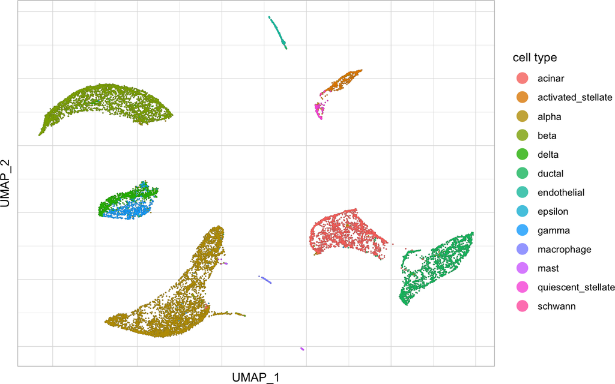

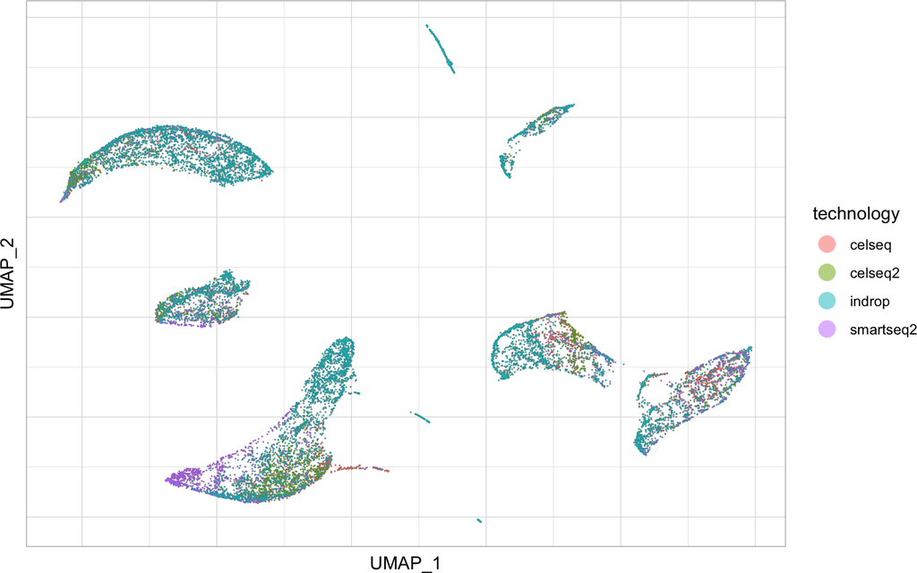

Figure 1: Integrated pancreas islet cells data sests from four technologies

```r
tech = do.call(c, lapply(data.list$metadata.list[ref.data], function(x) x$tech))
celltype = do.call(c, data.list$labels.list[ref.data])
umap.out = plot_umap(X=Hnorm, labels=celltype,
                     pca = NULL, n_components = 2, n_neighbors = 50, min_dist = 0.1, # umap parameters
                     point.size = 0.6, alpha=0.8, title=NULL, legend.name='cell type', # figure parameters
                     seed=42)

p1 = umap.out$p # colored by technologies
p2 = plot_umap(labels=tech, point.size = 0.5, alpha=0.5, legend.name='technology', emb=umap.out$emb)$p # colored by cell types
p1
p2
```

Calculate the alignment score for each datasets

```r
alignment.score.out = calculate_alignment(X.list=list(Hnorm), k=30, balanced=F, dataset=tech, labels=celltype)
alignment.score.out$alignment.per.dataset
```

```
#>    celseq   celseq2    indrop smartseq2
#> 0.6760087 0.6680045 0.6051005 0.6247078
```

## 2.2 Data transfer

Next we transfer the learned factor matrix to the smallest data set, containing 638 cells from fluidigmc1 technology.

```r
# transfer: run time 10 seconds
tf.out = CFITTransfer(Xtarget=exprs.list[[4]], Wref=int.out$W, max.niter = 100, seed=0, verbose=F)
```

Visualize the transferred results via UMAP plot,

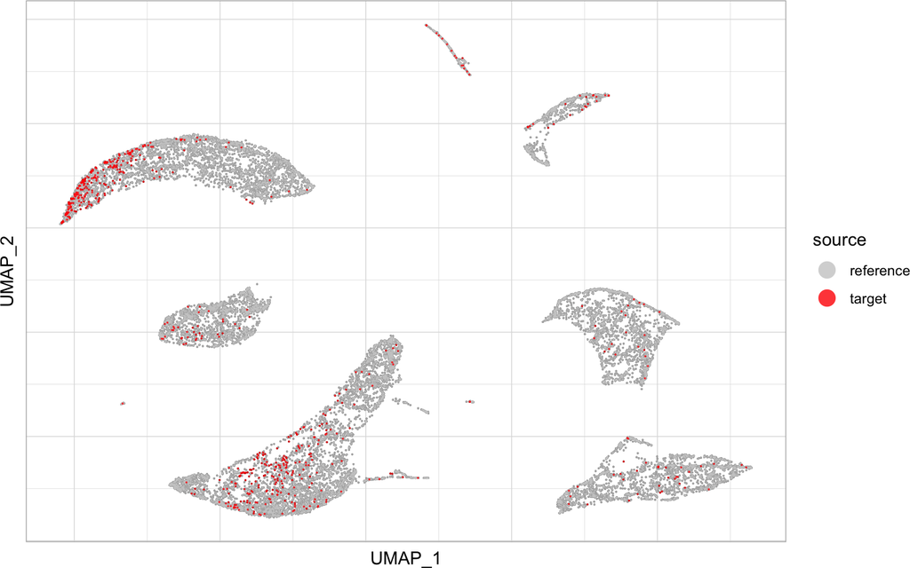

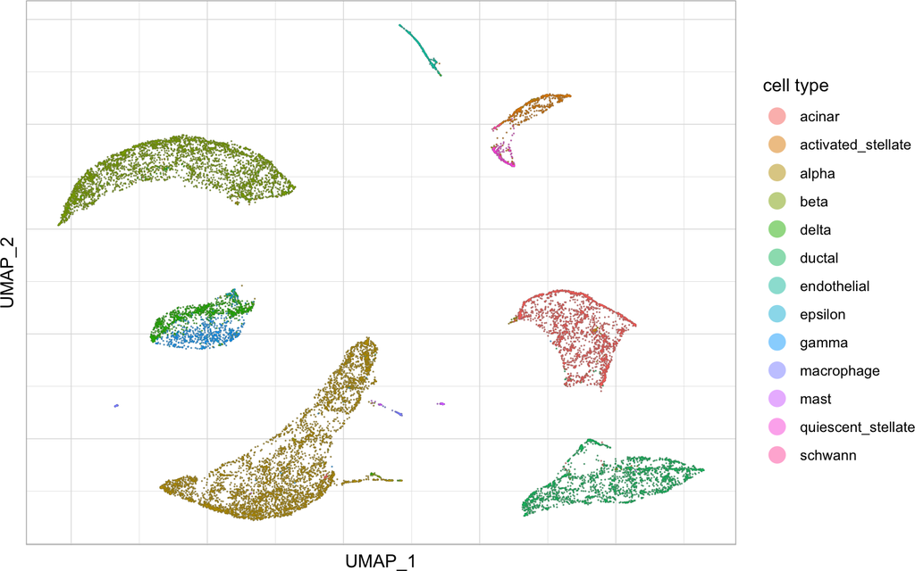

Figure 2: cFIT transfer results

```r
Hnorm = rbind(do.call(rbind, int.out$H.list), tf.out$H) %*% diag(colSums(int.out$W))
source = rep(c('reference','target'), c(nrow(do.call(rbind, int.out$H.list)), nrow(tf.out$H)))
celltype = do.call(c, c(data.list$labels.list[ref.data],data.list$labels.list[4]))

umap.out = plot_umap(X=Hnorm, labels=source, min_dist = 0.1, # umap parameters
                     point.size = 0.6, alpha=0.8, title=NULL, legend.name='source',
                     cols=c('grey80','red'), seed=0)

p1 = umap.out$p # colored by source
p2 = plot_umap(labels=celltype, point.size = 0.5, alpha=0.5, legend.name='cell type',
               emb=umap.out$emb)$p # colored by cell types
p1
p2
```

Assign labels for each cell in the target data by querying the cell type of target cells within k nearest neighbors.

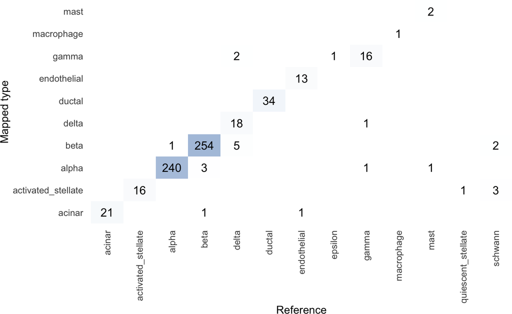

```r
est.labels = asign_labels(exprs.source=do.call(rbind, int.out$H.list),
                           exprs.target=tf.out$H,
                           labels.source=do.call(c, data.list$labels.list[ref.data]))
plotContTable(est_label=est.labels, true_label=data.list$labels.list[[4]], ylab='Mapped type')
```

# 3 Simulated data

We provide tools for simulating data sets. The data can be generated either from our proposed model, or from models provided by a widely employed scRNAseq data simulator [Splatter](https://github.com/Oshlack/splatter) package (Zappia, Phipson, and Oshlack (2017))

## 3.1 Simulate from model

```r
data.out = generate_data(n=2000, p=500, ntask=5, K=6, cl.sep=1, sig=1, batch.effect.sig=1, alpha=0.5)
```

where the ouput contains all the simulated expression matrix saved in a list `X.list` and all the model parameters `W`, `H.list`, `lambda.list`, `b.list`. We can see the the simulated data is grouped by both cluster and batch.

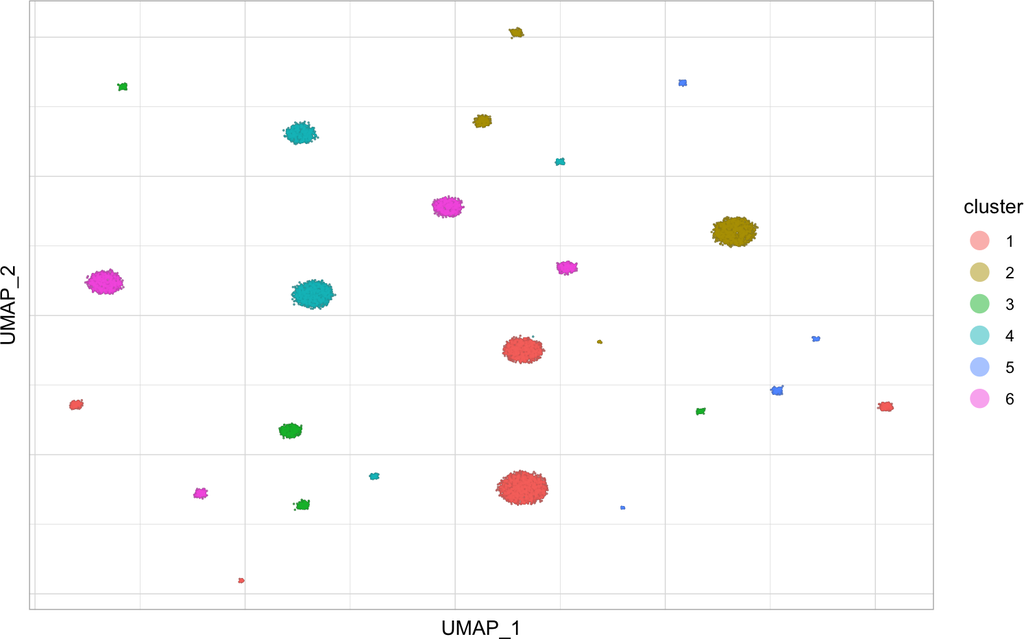

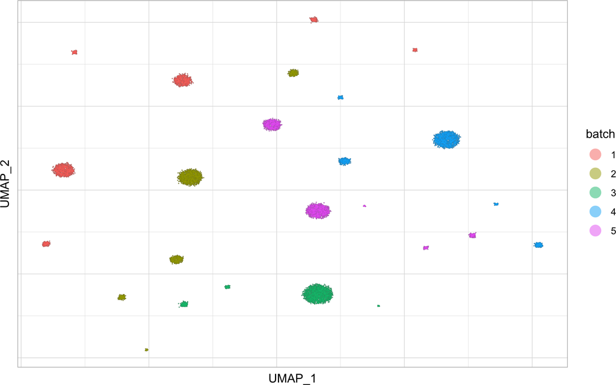

Figure 3: Simulated data

```r
labels = as.character(do.call(c, data.out$label.list))
batchs = as.character(rep(1:length(data.out$X.list), each=length(data.out$label.list[[1]])))

umap.out = plot_umap(X=do.call(rbind, data.out$X.list), labels=labels,
                     min_dist = 0.4, point.size = 0.6, alpha = 0.5, legend.name = 'cluster')
p1 = umap.out$p
p2 = plot_umap(labels=batchs, point.size = 0.5, alpha=0.5, legend.name='batch',  emb=umap.out$emb)$p

p1
p2
```

By cFIT we get the integrated results

```r
int.out = CFITIntegrate(X.list=data.out$X.list, r=6, max.niter = 100, seed=0, verbose=F)
```

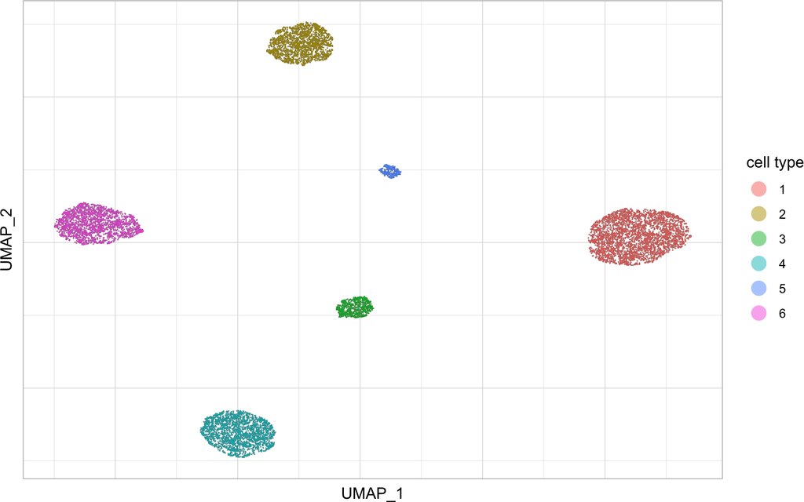

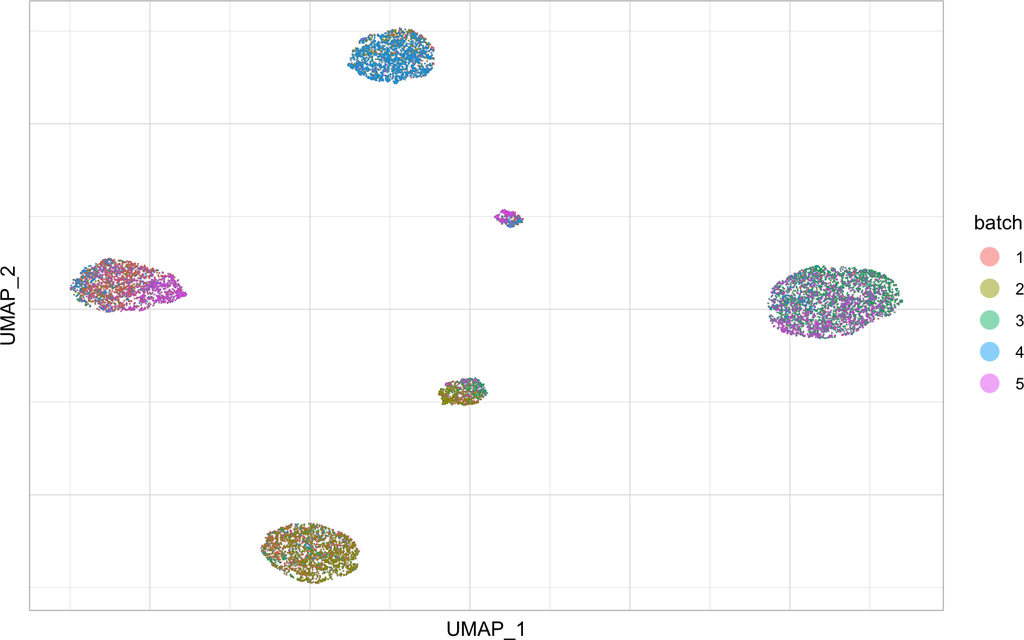

Figure 4: Simulated data from assumed model with batch effects corrected applying cFIT

```r
Hnorm = do.call(rbind, int.out$H.list) %*% diag(colSums(int.out$W))
umap.out = plot_umap(X=Hnorm, labels=labels, point.size = 0.5, alpha=0.5, legend.name='cell type')

p1 = umap.out$p # colored by technologies
p2 = plot_umap(labels=batchs, point.size = 0.5, alpha=0.5, legend.name='batch', emb=umap.out$emb)$p # colored by cell types
p1
p2
```

# 4 Algorithm speed up

The computation complexity of cFIT scales linearly with the number of cells. It can accommodate tens of thousands of cells within reasonable run time on a standard PC (depending on the number of genes, `p`, and the number of factors `r`). To speed up the processing of millions of cells, we implemented a fast version of the algorithm employing the idea of random sketching and stochastic proximal point method (SPP). Details can be found in our manuscipts.

The speed up version is implemented by `CFITIntegrate_sketched` function. The usage is similar to `CFITIntegrate` with two additional parameters:

- `subsample.prop`: the fraction to be subsampled in each parameter update, in range (0,1]. Default is set to `min(5*10^4/n, 1)`. Smaller value will results in faster computation for each iteration, but too small the value would result in higher estimation error.
- `weight.list`: a list of vectors of weights for the corresonding samples saved as a list of data matrices `X.list`. If provided, cells will be subsampled based on the relative weights instead of uniformly.

We examine the performance of the speed up with the following experiments:

```r
n = 2e5
subsample.prop.list = c(1,.1,.01,.001)

ntask = 5 # five batches in total
p = 500 # number of genes
r = 10 # number of factors
nrep = 1
time.out = 120 # stop running after 120 minutes

runtime.mat = matrix(NA, nrep, length(subsample.prop.list))
obj.mat = matrix(NA, nrep, length(subsample.prop.list))
info.list = list()

set.seed(42)
data.out = generate_data(n=n, p=p, ntask=ntask, K=r, cl.sep=1, sig=2, batch.effect.sig=0.5, alpha=1)
for(rep in 1:nrep){
    message('repeat: ',rep)
    for (j in 1:length(subsample.prop.list)){
        subsample.prop = subsample.prop.list[j]
        message('subsample.prop=',subsample.prop,'...')

        int.out = CFITIntegrate_sketched(X.list=data.out$X.list, r=r, verbose=T, subsample.prop=subsample.prop,
                                         tol=1e-6*subsample.prop, early.stopping=50, time.out=time.out,
                                         seed=rep, future.plan='sequential', max.niter=50/subsample.prop)

        time = int.out$time.elapsed
        message('Finish, run ', int.out$niter,' iters in time:', time,'.')

        runtime.mat[rep,j] = time
        obj.mat[rep,j] = int.out$obj
        info.list = c(info.list,list(list(n = n,
                                          subsample.prop = subsample.prop,
                                          rep = rep,
                                          deltaw.history = int.out$deltaw.history,
                                          obj.history = int.out$obj.history,
                                          time.elapse.history = int.out$time.elapse.history)))
    }
}
res = list(runtime.mat=runtime.mat, obj.mat=obj.mat, info.list=info.list, n = n,
           subsample.prop.list=subsample.prop.list, p=p, ntask=ntask, r=r, nrep=nrep)
```

Examine the objective function versus run time for different subsampling fraction used

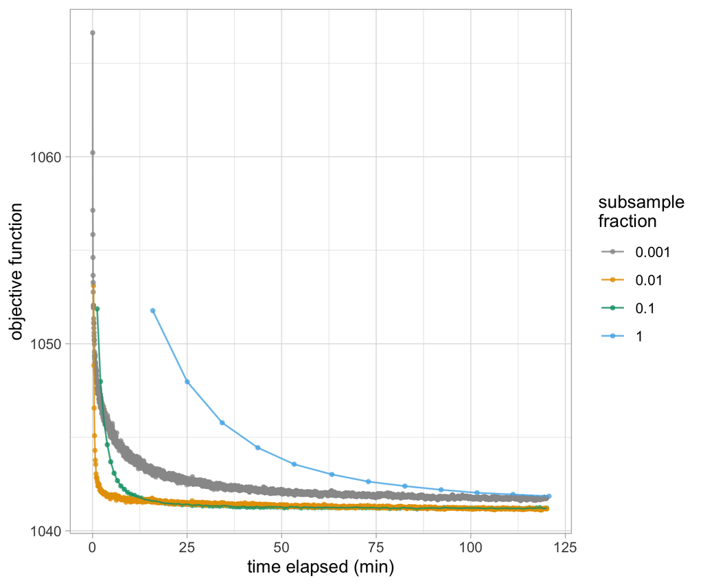

Figure 5: Examine the objective function versus run time using sketched cFIT with varying subsampling fractions

```r
df = data.frame(subsample.prop = rep(as.character(res$subsample.prop.list), sapply(res$info.list, function(x) length(x$obj.history))),
                obj = do.call(c, lapply(res$info.list, function(x) x$obj.history)),
                time.elapsed = do.call(c, lapply(res$info.list, function(x) x$time.elapse.history)))
df.plot = df[df$subsample.prop %in% c(1,.1,.01,.001),]
ggplot(df.plot, aes(x = time.elapsed, y = obj, col=subsample.prop)) +
    geom_point(alpha=0.8,stroke = 0) + geom_line(alpha=0.8) + theme_light() +
    labs(color='subsample\nfraction', y='objective function', x='time elapsed (min)') +
    scale_color_manual(values = c("#999999",  "#E69F00",  "#009E73","#56B4E9"))
```

# Reference

Stuart, Tim, Andrew Butler, Paul Hoffman, Christoph Hafemeister, Efthymia Papalexi, William M Mauck III, Yuhan Hao, Marlon Stoeckius, Peter Smibert, and Rahul Satija. 2019. “Comprehensive Integration of Single-Cell Data.” *Cell* 177 (7): 1888–1902.

Zappia, Luke, Belinda Phipson, and Alicia Oshlack. 2017. “Splatter: Simulation of Single-Cell RNA Sequencing Data.” *Genome Biology* 18 (1): 1–15.